# Pleural Effusions After Lung Transplant and Their Relationship to Acute Cellular Rejection

## 0.1 Preliminaries

```r
library(skimr)
library(broom)
library(leaps)
library(modelr)
library(rms)
library(tidyverse)
library(simputation)
```

# 1 Task 1: Data Source

This data was hand collected by me from electronic medical records during my residency. The data collection was performed under an IRB addressing rejection after lung transplant.

# 2 Task 2: Load and Tidy the Data

```r
Pleural <- read.csv("data_pleural.csv", stringsAsFactors = TRUE) %>% tbl_df
skim(Pleural)
```

```
Skim summary statistics
 n obs: 130
 n variables: 24

Variable type: factor
 variable missing complete   n n_unique                       top_counts
   gender       0      130 130        2          mal: 81, fem: 49, NA: 0
  lung_dx       0      130 130        6 IPF: 63, COP: 39, CF: 17, Bro: 6
 ordered
   FALSE
   FALSE

Variable type: integer
       variable missing complete   n    mean       sd p0   p25 median
            age       0      130 130   58.98    14.4  17  54     63.5
         cxr_60       3      127 130    0.66     0.7   0   0      1
       cxr_post       2      128 130    1.16     0.78  0   1      1
        cxr_pre       0      130 130    1.59     0.8   0   1      1
 infxn_1stthora       0      130 130    0.15     0.35  0   0      0
            ldh       6      124 130  569.24  1678.78  0 139    208
          lymph       5      125 130   55.17    30.01  0  33     66
            pmn       5      125 130   21.47    27.75  0   2      9
    post_fev130      24      106 130   60.95    15.31 26  50     61
     post_fvc30      24      106 130   57.89    14.23 22  48     58.5
     pre_fev130      21      109 130   58.69    16.16 11  49     57
      pre_fvc30      21      109 130   58.37    13.63 30  48     58
     proc_bil_1       0      130 130    0.72     0.45  0   0      1
   recurrenteff       0      130 130    0.38     0.49  0   0      0
         rej_60       0      130 130    0.28     0.45  0   0      0
        studyid       0      130 130   83.98    46.39  1  46.5   84.5
      thoratime       0      130 130  113.81   186.78 14  27     36
       timetodc       0      130 130   24.31    30.9   4  11     13.5
         volume       4      126 130  496.06   378.64  1 200    425
            wbc       7      123 130 3899.41 10689.19 61 496.5 1288
     p75  p100     hist
   69       79 ▁▁▁▁▂▅▇▂
    1        3 ▇▁▇▁▁▂▁▁
    2        4 ▃▇▁▃▁▁▁▁
    2        4 ▁▇▁▅▁▂▁▁
    0        1 ▇▁▁▁▁▁▁▂
```

[output cut: 8 more lines]

```
    1        1 ▇▁▁▁▁▁▁▅
    1        1 ▇▁▁▁▁▁▁▃
  122      167 ▆▇▇▇▇▇▇▆
   78.25   928 ▇▁▁▁▁▁▁▁
   25      198 ▇▁▁▁▁▁▁▁
  700     2000 ▇▆▅▃▁▁▁▁
 3023    1e+05 ▇▁▁▁▁▁▁▁

Variable type: numeric
 variable missing complete   n mean   sd   p0 p25 median  p75 p100
       ph       9      121 130 7.42 0.12 6.89 7.4   7.44 7.49 7.64
  protein       7      123 130 2.78 0.82 0    2.2   2.8  3.4  4.9
     hist
 ▁▁▁▁▂▇▇▁
 ▁▁▂▅▇▆▃▁
```

```r
str(Pleural)
```

```
Classes 'tbl_df', 'tbl' and 'data.frame':   130 obs. of  24 variables:
 $ studyid       : int  1 2 3 4 6 7 9 11 13 14 ...
 $ gender        : Factor w/ 2 levels "female","male": 1 1 2 1 1 2 1 2 1 2 ...
 $ age           : int  52 58 65 68 64 66 70 70 54 67 ...
 $ lung_dx       : Factor w/ 6 levels "Bronchiectasis",..: 4 3 4 3 3 4 3 3 4 4 ...
 $ timetodc      : int  84 12 14 11 17 13 13 24 22 11 ...
 $ proc_bil_1    : int  1 1 1 1 0 1 1 1 1 0 ...
 $ thoratime     : int  49 27 41 93 112 48 26 20 41 22 ...
 $ rej_60        : int  0 1 1 0 0 1 0 0 1 1 ...
 $ recurrenteff  : int  0 0 1 1 1 1 1 1 0 0 ...
 $ infxn_1stthora: int  0 0 0 0 0 1 0 0 0 0 ...
 $ volume        : int  200 390 320 720 350 1100 850 100 460 700 ...
 $ wbc           : int  64 4078 NA 223 158 12161 322 108 2074 2942 ...
 $ pmn           : int  54 1 NA 1 2 13 0 10 25 0 ...
 $ lymph         : int  16 84 NA 9 88 78 45 70 72 81 ...
 $ ldh           : int  542 135 272 143 131 392 99 74 254 254 ...
 $ ph            : num  7.52 7.45 7.37 7.45 7.38 7.41 7.5 7.51 7.64 7.42 ...
 $ protein       : num  1.9 2.8 3.1 3.9 2.5 2.9 2.9 1.5 3.8 3.3 ...
 $ pre_fvc30     : int  NA 48 46 51 56 65 72 53 56 46 ...
 $ pre_fev130    : int  NA 57 49 56 66 71 87 61 53 51 ...
 $ post_fvc30    : int  NA 53 48 55 56 58 61 65 51 52 ...
 $ post_fev130   : int  NA 61 51 55 66 61 69 79 36 62 ...
 $ cxr_pre       : int  4 2 1 2 2 2 1 1 3 1 ...
 $ cxr_post      : int  2 2 1 1 2 3 2 0 2 1 ...
 $ cxr_60        : int  1 0 0 0 2 0 1 1 2 1 ...
```

```r
pleural1 <- Pleural %>%
  mutate(ID = as.character(studyid),
proc.bil = factor(proc_bil_1),
rej60 = factor(rej_60),
gender = ifelse(gender=="female",1,0),
effrec = factor(recurrenteff),
infxn = factor(infxn_1stthora))
pleural <- pleural1 %>% select(ID, gender, age, lung_dx, proc.bil, timetodc, thoratime, rej60, effrec, infxn, volume, wbc, pmn, lymph, ldh, ph, protein)
str(pleural)
```

```
Classes 'tbl_df', 'tbl' and 'data.frame':   130 obs. of  17 variables:
 $ ID       : chr  "1" "2" "3" "4" ...
 $ gender   : num  1 1 0 1 1 0 1 0 1 0 ...
 $ age      : int  52 58 65 68 64 66 70 70 54 67 ...
 $ lung_dx  : Factor w/ 6 levels "Bronchiectasis",..: 4 3 4 3 3 4 3 3 4 4 ...
 $ proc.bil : Factor w/ 2 levels "0","1": 2 2 2 2 1 2 2 2 2 1 ...
 $ timetodc : int  84 12 14 11 17 13 13 24 22 11 ...
 $ thoratime: int  49 27 41 93 112 48 26 20 41 22 ...
 $ rej60    : Factor w/ 2 levels "0","1": 1 2 2 1 1 2 1 1 2 2 ...
 $ effrec   : Factor w/ 2 levels "0","1": 1 1 2 2 2 2 2 2 1 1 ...
 $ infxn    : Factor w/ 2 levels "0","1": 1 1 1 1 1 2 1 1 1 1 ...
 $ volume   : int  200 390 320 720 350 1100 850 100 460 700 ...
 $ wbc      : int  64 4078 NA 223 158 12161 322 108 2074 2942 ...
 $ pmn      : int  54 1 NA 1 2 13 0 10 25 0 ...
 $ lymph    : int  16 84 NA 9 88 78 45 70 72 81 ...
 $ ldh      : int  542 135 272 143 131 392 99 74 254 254 ...
 $ ph       : num  7.52 7.45 7.37 7.45 7.38 7.41 7.5 7.51 7.64 7.42 ...
 $ protein  : num  1.9 2.8 3.1 3.9 2.5 2.9 2.9 1.5 3.8 3.3 ...
```

## 2.1 Specifications of Data Tidying

In my original .csv file, I had encoded NA’s as “.” which was done long before I took this class and is in general a bad idea. I then used find and replace to replace . with NA which then took away my decimal places. I remedied this before bringing in the data. When I initially brought in the data, there were no decimals in pH and protein so I included stringsasfactors = TRUE in my data import. I then changed the procedure type, 60 day rejection, recurrent effusion, and infection to factor varibles. The other variables were characterized correctly.

# 3 Task 3: Listing of My Tibble

```r
str(pleural)
```

```
Classes 'tbl_df', 'tbl' and 'data.frame':   130 obs. of  17 variables:
 $ ID       : chr  "1" "2" "3" "4" ...
 $ gender   : num  1 1 0 1 1 0 1 0 1 0 ...
 $ age      : int  52 58 65 68 64 66 70 70 54 67 ...
 $ lung_dx  : Factor w/ 6 levels "Bronchiectasis",..: 4 3 4 3 3 4 3 3 4 4 ...
 $ proc.bil : Factor w/ 2 levels "0","1": 2 2 2 2 1 2 2 2 2 1 ...
 $ timetodc : int  84 12 14 11 17 13 13 24 22 11 ...
 $ thoratime: int  49 27 41 93 112 48 26 20 41 22 ...
 $ rej60    : Factor w/ 2 levels "0","1": 1 2 2 1 1 2 1 1 2 2 ...
 $ effrec   : Factor w/ 2 levels "0","1": 1 1 2 2 2 2 2 2 1 1 ...
 $ infxn    : Factor w/ 2 levels "0","1": 1 1 1 1 1 2 1 1 1 1 ...
 $ volume   : int  200 390 320 720 350 1100 850 100 460 700 ...
 $ wbc      : int  64 4078 NA 223 158 12161 322 108 2074 2942 ...
 $ pmn      : int  54 1 NA 1 2 13 0 10 25 0 ...
 $ lymph    : int  16 84 NA 9 88 78 45 70 72 81 ...
 $ ldh      : int  542 135 272 143 131 392 99 74 254 254 ...
 $ ph       : num  7.52 7.45 7.37 7.45 7.38 7.41 7.5 7.51 7.64 7.42 ...
 $ protein  : num  1.9 2.8 3.1 3.9 2.5 2.9 2.9 1.5 3.8 3.3 ...
```

## 3.1 Tibble dimensions

There are 130 subjects (rows) There are 16 variables + study ID (columns)

# 4 Task 3b: Imputing Data (pleural2 data)

```r
set.seed(24601)
pleural2 <- pleural %>%
impute_pmm(lymph ~ volume + thoratime + rej60)
```

```r
pleural2 %>% select(lymph) %>% skim
```

```
Skim summary statistics
 n obs: 130
 n variables: 1

Variable type: integer
 variable missing complete   n  mean    sd p0   p25 median p75 p100
    lymph       0      130 130 55.14 29.45  0 34.25     64  79   98
     hist
 ▆▃▂▃▅▆▇▆
```

# 5 Task 4: Code Book

The data includes a number of variables, some of which are not included in this analysis:

| Variable | Type | Details |
| --- | --- | --- |
| `studyid` | ID | Study ID |
| `gender` | categorical | male or female (1 = female, 0 = male) |
| `age` | quantitative | age in years |
| `lung_dx` | categorical | diagnosis leading to lung transplant |
| `proc_bil_1` | categorical | type of procedure, 1 = bilateral lung transplant, 0 = single lung transplant |
| `thoratime` | quantitative | time in days to first thoracentesis |
| `rej_60` | categorical | acute rejection by biopsy within 60 days of transplant, 1 = yes, 0 = no |
| `recurrent_eff` | categorical | presence of repeated pleural effusions, 1 = yes, 0 = no |
| `infxn_1stthora` | categorical | was infection present in pleural fluid, 1 = yes, 0 = no |
| `volume` | quantitative | volume in mL removed at thoracentesis |
| `wbc` | quantitative | number of white cells in pleural fluid per high power field |
| `pmn` | quantitative | percent of neutrophils in pleural fluid per high power field (0-100%) |
| `lymph` | quantitative | percent of lymphocytes in pleural fluid per high power field (0-100%) |
| `ldh` | quantitative | value of lactate dehydrogenase in pleural fluid, units IU/L |
| `protein` | quantitative | value of protein in pleural fluid, units g/dL |
| `ph` | quantitative | pH value of pleural fluid |
| `timetodc` | quantitative | time to discharge in days |

# 6 Task 5: My Subjects

The data describes a sample of 130 patients who were found to have a pleural effusion after 2 weeks following lung transplant. The two questions for this dataset are: 1. What factors influence the time to pleural effusion? 2. What factors influence the development of acute cellular rejection? The lung transplant community believes that there may be an association between presence of pleural fluid and rejection although this has been poorly studied.

# 7 Task 6: My Variables:

- Of note, I have included more variables then I intend to use, but these may be useful for further analysis, so I kept them in here. I am happy to remove them for the final project if you prefer.

gender: Missing 0. Levels (2): Male, Female. female or male.

age: Missing 0. Range: 17-79 Units: Years. Age at time of lung transplant

lung_dx: Missing 0. Levels (6): The indication for lung transplant, typically a lung disease such as chronic obstructive pulmonary disease (COPD) (30%), idiopathic pulmonary fibrosis (IPF) (48.5%), cystic fibrosis (CF) (13.1%), sarcoidosis (2.3%), Pulmonary hypertension (1.5%) or bronchiectasis (4.6%).

proc_bil_1: Missing 0. Levels (2): The type of transplant procedure, there are two options, bilateral (71.5%) or single (28.5%). Bilateral is typically done in younger and more fit patients.

thoratime: Missing 0. Range: 14-928 Units: Days. Time from lung transplant to thoracentesis (procedure where fluid is drained from the pleural space surrounding the lung)

rej_60: Missing 0. Levels (2), 71.5% with no rejection, 28.5% with rejection. The presence of acute cellular rejection, diagnosed by bronchoscopic biopsy

recurrent_eff: Missing 0. Levels (2), 62.3% without recurrent effusion, 37.7% with recurrent effusion. Did the patient have more than one episode of pleural effusion?

infxn_1stthora: Missing 0. Levels (2), 85.4% without infection, 14.6% with infection. Was there an infection at the time of pleural fluid sampling?

Volume: Missing 4. Range: 1-2000 Units: mL The volume removed in mL of pleural fluid during the thoracentesis.

wbc: Missing 7. Range: 61-100000, Units: per HPF. The number of white cells in pleural fluid per high power field. Higher WBC are concerning for infection.

pmn: Missing 5. Range:0-93, Units: percent. The % of neutrophils in WBC in pleural fluid. Higher PMN (a subset of WBC) are concerning for infection.

lymph: Missing 5. Range 0-98, Units: percent. The % of lymphocytes in WBC in pleural fluid. Can be associated with rare causes of pleural effusion such as certain infections and may be seen in higher numbers in pleural effusions associated with rejection.

Ldh: Missing 6. Range: 0-12853, Units: IU/L. The value of lactate dehydrogenase in pleural fluid. This is used in determining if fluid is a transudate or an exudate which is an important diagnostic classification for pleural effusions.

pH: Missing 9. Range 6.89-7.64, Units: pH units. Measure of acidity of pleural fluid.

protein: Missing 7 Range: 0-4.9, Units: g/dL. The value of protein in pleural fluid. This is used in determining if fluid is a transudate or an exudate which is an important diagnostic classification for pleural effusions.

timetodc: Missing 0. Range: 4-198, Units: Days. Time to discharge in days after lung transplant.

# 8 Task 7: My Planned Linear Regression Model

The quantitative variable that will be my outcome is time to thoracentesis. Categorical predictor variables include lung disease (multi-categorical), age (quantitative), bilateral procedure (categorical), and time to discharge (quantitative).

# 9 Task 8: My Planned Logistic Regression Model

The binary variable that will be my outcome is rejection at sixty days (1= yes, 0 = no). Candidate predictors include lung disease (multi-categorical), time to thoracentesis (quantitative), presence of infection (categorical), and lymphocyte percentage (quantitative).

# 10 Task 9: Affirmation

I am certain that it is completely appropriate for these data to be shared with anyone, without any conditions. There are no concerns about privacy or security.

# 11 Task 10 Analysis: Linear Regression

# 12 Looking at Our Outcome

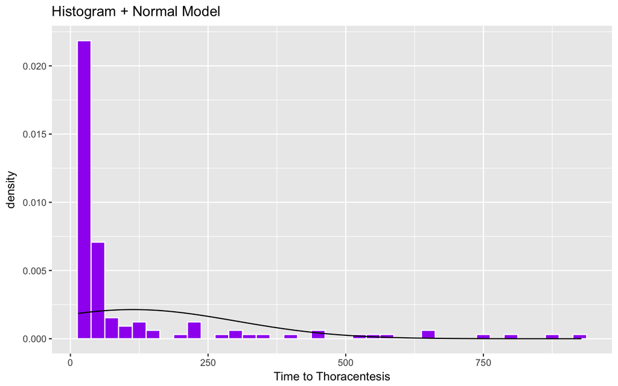

```r
p1 <- ggplot(pleural2, aes(x = thoratime)) +
geom_histogram(aes(y = ..density..),
binwidth=25, fill = "purple", color = "white") +
stat_function(fun = dnorm, args = list(mean = mean(pleural2$thoratime),
sd = sd(pleural2$thoratime))) +
labs(x = "Time to Thoracentesis", title="Histogram + Normal Model")
p1
```

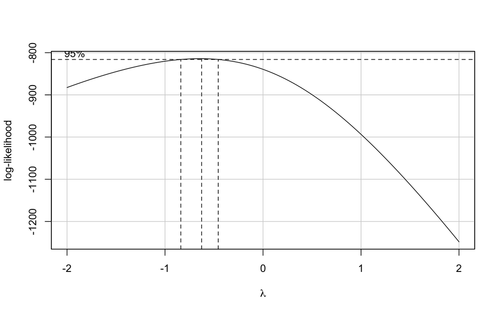

```r
library(car)
boxCox(pleural2$thoratime ~ pleural2$timetodc + pleural2$age)
```

# 13 I will run the log, negative 1/2 and 1/2 based on the box cox plot.

```r
testTransform(powerTransform(pleural2$thoratime ~ pleural2$timetodc + pleural2$age), 0)
```

```
                           LRT df         pval
LR test, lambda = (0) 50.55042  1 1.161404e-12
```

```r
testTransform(powerTransform(pleural2$thoratime ~ pleural2$timetodc + pleural2$age), -0.5)
```

```
                              LRT df      pval
LR test, lambda = (-0.5) 2.244334  1 0.1341046
```

```r
testTransform(powerTransform(pleural2$thoratime ~ pleural2$timetodc + pleural2$age), 0.5)
```

```
                             LRT df pval
LR test, lambda = (0.5) 170.6924  1    0
```

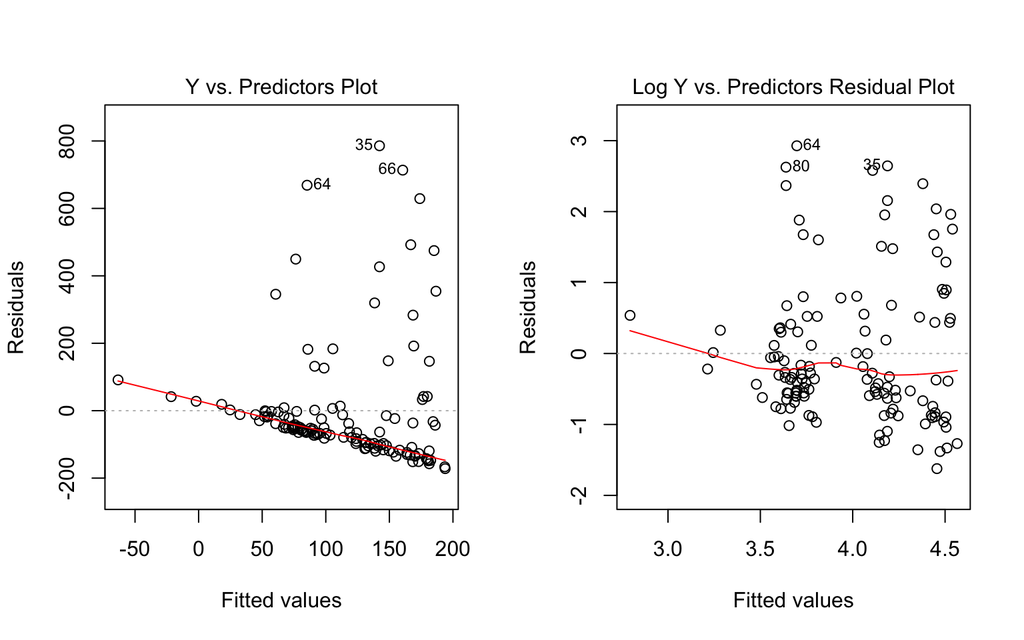

```r
model.orig <- lm(thoratime ~ lung_dx + age + proc.bil + timetodc, data=pleural2)
model.sqrt <- lm(log(pleural2$thoratime) ~ lung_dx + age + proc.bil + timetodc, data=pleural2)
par(mfrow=c(1,2))
plot(model.orig, which = 1, caption = "Y vs. Predictors Plot")
plot(model.sqrt, which = 1, caption = "Log Y vs. Predictors Residual Plot")
```

The residual values look slightly better in the log residual plot.

# 14 Table 1

```r
library(tableone)
fs.vars<- c("age", "timetodc", "thoratime", "lymph", "gender", "lung_dx", "proc.bil", "infxn")
fs.factorvars <- c("gender", "lung_dx", "proc.bil", "infxn")
tableOne <- CreateTableOne(data = pleural2,
               vars = fs.vars,
               factorVars = fs.factorvars,
               strata = c("rej60"))
summary(tableOne)
```

```
     ### Summary of continuous variables ###

rej60: 0
           n miss p.miss mean  sd median p25 p75 min max skew kurt
age       93    0      0   59  15     65  53  69  17  79 -1.4    1
timetodc  93    0      0   24  29     14  10  25   5 196  3.9   18
thoratime 93    0      0  129 202     40  28 112  17 928  2.5    6
lymph     93    0      0   51  31     57  19  78   0  94 -0.4   -1
--------------------------------------------------------
rej60: 1
           n miss p.miss mean  sd median p25 p75 min max skew kurt
age       37    0      0   59  13     63  58  66  22  77   -2  2.1
timetodc  37    0      0   26  36     13  11  25   4 198    4 14.8
thoratime 37    0      0   77 139     31  22  41  14 660    3 11.3
lymph     37    0      0   64  21     68  51  80   6  98   -1  0.9

p-values
             pNormal pNonNormal
age       0.81056636 0.58412544
timetodc  0.69532024 0.88905092
thoratime 0.15446678 0.01505780
lymph     0.02347012 0.07932116

Standardize mean differences
              1 vs 2
age       0.04848199
timetodc  0.07240385
thoratime 0.29938366
lymph     0.48001258

=======================================================================================

     ### Summary of categorical variables ###

rej60: 0
      var  n miss p.miss          level freq percent cum.percent
   gender 93    0    0.0              0   58    62.4        62.4
                                      1   35    37.6       100.0

  lung_dx 93    0    0.0 Bronchiectasis    5     5.4         5.4
```

[output cut: 30 more lines]

```


p-values
            pApprox     pExact
gender   1.00000000 1.00000000
lung_dx  0.06722527 0.08135623
proc.bil 0.19171615 0.13930012
infxn    0.54783545 0.41440234

Standardize mean differences
              1 vs 2
gender   0.004196794
lung_dx  0.661449035
proc.bil 0.309327706
infxn    0.165021249
```

```r
print(tableOne)
```

```
                       Stratified by rej60
                        0               1              p      test
  n                         93             37
  age (mean (sd))        58.78 (15.11)  59.46 (12.60)   0.811
  timetodc (mean (sd))   23.63 (28.72)  26.00 (36.19)   0.695
  thoratime (mean (sd)) 128.55 (201.54) 76.76 (138.69)  0.154
  lymph (mean (sd))      51.46 (31.44)  64.38 (21.44)   0.023
  gender = 1 (%)            35 (37.6)      14 (37.8)    1.000
  lung_dx (%)                                           0.067
     Bronchiectasis          5 ( 5.4)       1 ( 2.7)
     CF                     12 (12.9)       5 (13.5)
     COPD                   21 (22.6)      18 (48.6)
     IPF                    50 (53.8)      13 (35.1)
     PulmHtn                 2 ( 2.2)       0 ( 0.0)
     Sarcoid                 3 ( 3.2)       0 ( 0.0)
  proc.bil = 1 (%)          63 (67.7)      30 (81.1)    0.192
  infxn = 1 (%)             12 (12.9)       7 (18.9)    0.548
```

# 15 Spearman ρ2 plot

For the outcome time to thoracentesis, Spearman ρ2 plot shows that lung diagnosis (lung_dx) may be helpful and perhaps bilateral procedure (proc.bil) and maybe age would be helpful. I thought about adding a spline, but this won’t be helpful with a categorical variable and our quantitative variables are less important in this plot.

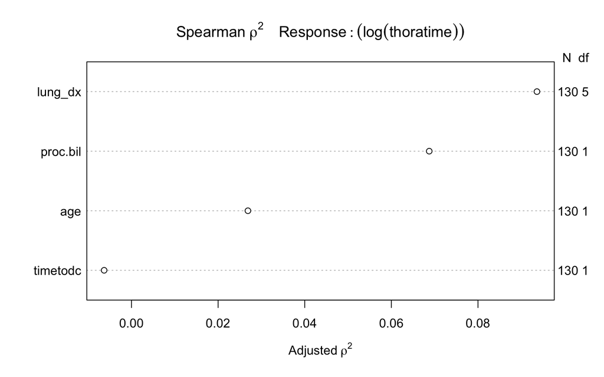

```r
plot(spearman2((log(thoratime)) ~ lung_dx + age + proc.bil + timetodc, data = pleural2))
```

```r
model1<- glm((log(thoratime)) ~ lung_dx + age + proc.bil + timetodc, data=pleural2)
summary(model1)
```

```
Call:
glm(formula = (log(thoratime)) ~ lung_dx + age + proc.bil + timetodc,
    data = pleural2)

Deviance Residuals:
    Min       1Q   Median       3Q      Max
-1.6227  -0.6302  -0.3379   0.4809   2.9279

Coefficients:
                Estimate Std. Error t value Pr(>|t|)
(Intercept)     4.066313   0.831794   4.889 3.15e-06 ***
lung_dxCF      -0.246751   0.560904  -0.440    0.661
lung_dxCOPD    -0.470275   0.459907  -1.023    0.309
lung_dxIPF      0.018783   0.468397   0.040    0.968
lung_dxPulmHtn -0.394564   0.846379  -0.466    0.642
lung_dxSarcoid  0.062008   0.734959   0.084    0.933
age             0.006552   0.010574   0.620    0.537
proc.bil1      -0.258273   0.264192  -0.978    0.330
timetodc       -0.004663   0.002969  -1.570    0.119
---
Signif. codes:  0 '***' 0.001 '**' 0.01 '*' 0.05 '.' 0.1 ' ' 1

(Dispersion parameter for gaussian family taken to be 1.07072)

    Null deviance: 146.62  on 129  degrees of freedom
Residual deviance: 129.56  on 121  degrees of freedom
AIC: 388.48

Number of Fisher Scoring iterations: 2
```

```r
# with OLS
d <- datadist(pleural2)
options(datadist = "d")

m.ols <- ols((log(thoratime)) ~ lung_dx + age + proc.bil + timetodc, data=pleural2, x = T, y = T)
m.ols
```

```
Linear Regression Model

 ols(formula = (log(thoratime)) ~ lung_dx + age + proc.bil + timetodc,
     data = pleural2, x = T, y = T)

                Model Likelihood     Discrimination
                   Ratio Test           Indexes
 Obs     130    LR chi2     16.08    R2       0.116
 sigma1.0348    d.f.            8    R2 adj   0.058
 d.f.    121    Pr(> chi2) 0.0412    g        0.410

 Residuals

     Min      1Q  Median      3Q     Max
 -1.6227 -0.6302 -0.3379  0.4809  2.9279


                 Coef    S.E.   t     Pr(>|t|)
 Intercept        4.0663 0.8318  4.89 <0.0001
 lung_dx=CF      -0.2468 0.5609 -0.44 0.6608
 lung_dx=COPD    -0.4703 0.4599 -1.02 0.3086
 lung_dx=IPF      0.0188 0.4684  0.04 0.9681
 lung_dx=PulmHtn -0.3946 0.8464 -0.47 0.6419
 lung_dx=Sarcoid  0.0620 0.7350  0.08 0.9329
 age              0.0066 0.0106  0.62 0.5367
 proc.bil=1      -0.2583 0.2642 -0.98 0.3302
 timetodc        -0.0047 0.0030 -1.57 0.1189
```

```r
anova(m.ols)
```

```
                Analysis of Variance          Response: (log(thoratime))

 Factor     d.f. Partial SS  MS        F    P
 lung_dx      5    4.6961366 0.9392273 0.88 0.4986
 age          1    0.4110527 0.4110527 0.38 0.5367
 proc.bil     1    1.0232856 1.0232856 0.96 0.3302
 timetodc     1    2.6407076 2.6407076 2.47 0.1189
 REGRESSION   8   17.0640601 2.1330075 1.99 0.0529
 ERROR      121  129.5571328 1.0707201
```

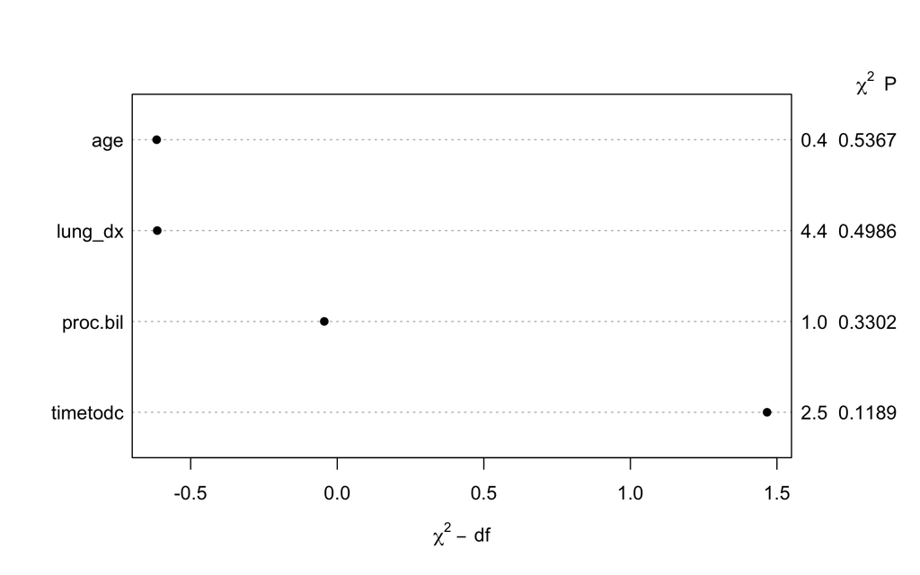

```r
plot(anova(m.ols))
```

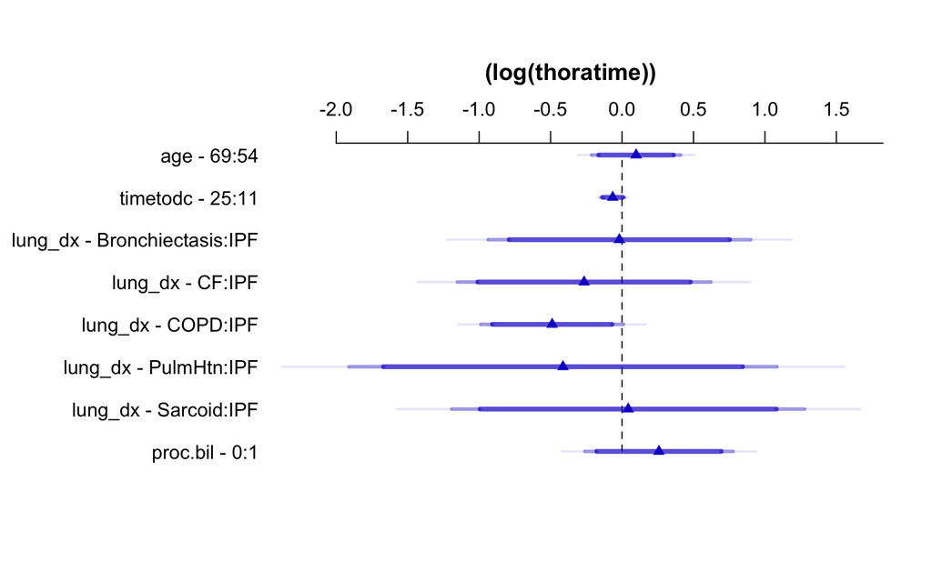

```r
plot(summary(m.ols))
```

## 15.1 ANOVA & plot summary

According to ANOVA, there are no statistically significant predictors for time to thora in this model. Our plot shows that all our variables estimates cross 0 and are not statistically significant.

## 15.2 Missingness

We do not have any missing values, so we do not need to impute any values for this portion of the analysis.

## 15.3 Best subsets:

I doubt this will be useful as none of our predictors seem to be helpful, but we’ll try.

```r
preds <- with(pleural2, cbind(lung_dx, age, proc.bil, timetodc))
rs.ks <- regsubsets(preds, y = pleural2$thoratime, nvmax=4)
rs.summ <- summary(rs.ks)
rs.summ
```

```
Subset selection object
4 Variables  (and intercept)
         Forced in Forced out
lung_dx      FALSE      FALSE
age          FALSE      FALSE
proc.bil     FALSE      FALSE
timetodc     FALSE      FALSE
1 subsets of each size up to 4
Selection Algorithm: exhaustive
         lung_dx age proc.bil timetodc
1  ( 1 ) " "     " " "*"      " "
2  ( 1 ) " "     " " "*"      "*"
3  ( 1 ) " "     "*" "*"      "*"
4  ( 1 ) "*"     "*" "*"      "*"
```

```r
rs.summ$aic.corr <- 130*log(rs.summ$rss / 130) + 2*(2:5) +
(2 * (2:5) * ((2:5)+1) / (130 - (2:5) - 1))
```

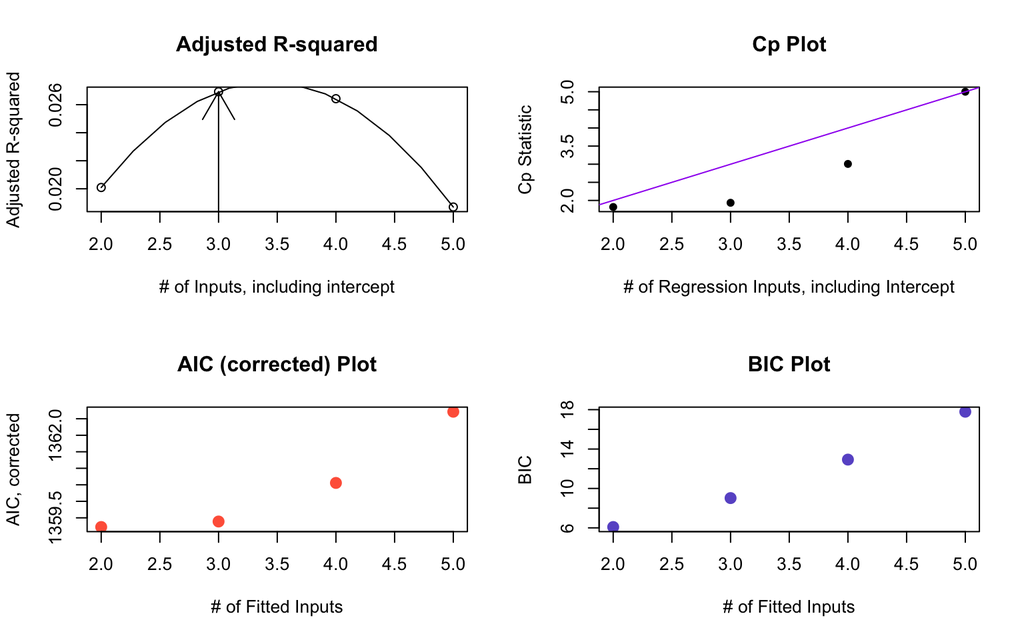

```r
par(mfrow=c(2,2))
m2 <- max(rs.summ$adjr2)
m1 <- which.max(rs.summ$adjr2) + 1
plot(rs.summ$adjr2 ~ I(2:5), ylab="Adjusted R-squared",
xlab="# of Inputs, including intercept",
main = "Adjusted R-squared")
lines(spline(rs.summ$adjr2 ~ I(2:5)))
arrows(m1, m2-0.02, m1, m2)

plot(rs.summ$cp ~ I(2:5),
ylab="Cp Statistic",
xlab="# of Regression Inputs, including Intercept",
pch=16, main="Cp Plot")
abline(0,1, col = "purple")

plot(rs.summ$aic.corr ~ I(2:5), ylab="AIC, corrected", xlab="# of Fitted Inputs",
pch=16, cex=1.5, col="tomato", main="AIC (corrected) Plot")

plot(rs.summ$bic ~ I(2:5), ylab="BIC", xlab="# of Fitted Inputs",
pch=16, cex=1.5, col="slateblue", main="BIC Plot")
```

## 15.4 Candidate Models from Best Subsets

[output not shown]